# Soju Ads - Analysis of Figurative Messaging

Bodo

2024-12-12

# 1 Intro

This analysis looks at Paula & Lucien’s annotated `dataset_2024.csv` file, which is a sample of all of our ads analyzed and annotated for figurative messaging.

# 2 Setup

Load libraries and data:

```r
# Packages:

library(tidyverse)   # for data processing and visualization
library(brms)        # for Bayesian models

# Data:

ads <- read_csv('../data/figurative_annotation_dataset_2024.csv')
```

Get an impression of this data:

```r
# First 4 lines:

ads |> print(n = 4, width = Inf)
```

```
## # A tibble: 589 × 10
##   Round item                                   id
##   <dbl> <chr>                               <dbl>
## 1    NA 25_1964_35_SeoGwang_Jinro_003          25
## 2     3 123_1997_25_KyeungWeol_Green_009      123
## 3     3 123_1997_25_KyeungWeol_Green_009      123
## 4     5 296_2004_21_JinRo_Chamjinisulro_005   296
##   main_slogan
##   <chr>
## 1 1924-1964 真味의 真露 EN: 1924-1964 The real taste, Jinro
## 2 부드러운 신입생환영회에는 부드러운 그린소주 EN: Smooth Green soju for a smoot…
## 3 부드러운 신입생환영회에는 부드러운 그린소주 EN: Smooth Green soju for a smoot…
## 4 고마워라는 말, 괜히 쑥스럽죠? 그냥 소주한잔 할까?라고 말해보세요 EN: For some…
##   secondary_slogan
##   <chr>
## 1 <NA>
## 2 <NA>
## 3 <NA>
## 4 소주가 있다! 참이슬이 있다! EN: There's soju! There's Chamisul!
##   Figuration                Label                  Frame1
##   <chr>                     <chr>                  <chr>
## 1 Personification_text      AGE IS AUTHENTICITY    SOJU ATTRIBUTES
## 2 Metonymy_other_background BALLOON FOR PARTY      FESTIVITY
## 3 Metonymy_other            BALLOON FOR PARTY      FESTIVITY
## 4 Metonymy_nature           BAMBOO FOR CLEANLINESS NATURE
##   Frame2          comments
##   <chr>           <chr>
## 1 SOJU ATTRIBUTES <NA>
## 2 <NA>            <NA>
## 3 <NA>            <NA>
## 4 <NA>            <NA>
## # ℹ 585 more rows
```

```r
# Some random lines:

ads |> sample_n(6)
```

```
## # A tibble: 6 × 10
##   Round item      id main_slogan secondary_slogan Figuration Label Frame1 Frame2
##   <dbl> <chr>  <dbl> <chr>       <chr>            <chr>      <chr> <chr>  <chr>
## 1     1 753_2…   753 가인이는 …  우리동네 잎새주… Metonymy_… GREE… GREEN  COLOUR
## 2     3 483_2…   483 추운겨울이… 100% 천연암반수… Metonymy_… SOJU… SOJU … SOJU …
## 3     3 4_196…     4 海外로 輸…  마셔보면 다시 …  Metonymy_… MONE… POP C… <NA>
## 4     2 479_2…   479 16.8도 상…  Think Casual EN… Personifi… WOMA… WOMAN  <NA>
## 5     4 81_19…    81 매취, 고요… Maechui - the A… Metaphor_… GOOD… KOREA… <NA>
## 6     5 159_1…   159 산소가 좋…  산이나 바다에서… Metonymy_… FISH… WATER  <NA>
## # ℹ 1 more variable: comments <chr>
```

```r
# Last couple lines:

slice_tail(ads, n = 10)
```

```
## # A tibble: 10 × 10
##    Round item     id main_slogan secondary_slogan Figuration Label Frame1 Frame2
##    <dbl> <chr> <dbl> <chr>       <chr>            <chr>      <chr> <chr>  <chr>
##  1    10 443_…   443 Merry Chri… <NA>             Personifi… WOMA… WOMAN  <NA>
##  2     3 736_…   736 노랑 뚜껑 … BARLEY SOJU EN:… Metonymy_… YELL… YELLOW COLOUR
##  3     9 15_1…    15 高級燒酎는… 寶盃燒酎의 맛은… Metonymy_… TAST… SOJU … SOJU …
##  4    NA <NA>     NA <NA>        <NA>             <NA>       <NA>  <NA>   <NA>
##  5    NA <NA>     NA <NA>        <NA>             <NA>       <NA>  <NA>   <NA>
##  6    NA <NA>     NA <NA>        <NA>             <NA>       <NA>  <NA>   <NA>
##  7    NA <NA>     NA <NA>        <NA>             <NA>       <NA>  <NA>   <NA>
##  8    NA <NA>     NA <NA>        <NA>             <NA>       <NA>  <NA>   <NA>
##  9    NA <NA>     NA <NA>        <NA>             <NA>       <NA>  <NA>   <NA>
## 10    NA <NA>     NA <NA>        <NA>             <NA>       <NA>  <NA>   <NA>
## # ℹ 1 more variable: comments <chr>
```

Last couple rows need fixing.

# 3 Processing

Get rid of the `NA` rows towards the end of the tibble.

```r
ads <- filter(ads, !is.na(item))

# Sanity check:

slice_tail(ads, n = 10)
```

```
## # A tibble: 10 × 10
##    Round item     id main_slogan secondary_slogan Figuration Label Frame1 Frame2
##    <dbl> <chr> <dbl> <chr>       <chr>            <chr>      <chr> <chr>  <chr>
##  1     7 743_…   743 이 맛에 산… 당이 없어 다음…  Personifi… WOMA… WOMAN  <NA>
##  2     9 744_…   745 브라보 청…  더 이상 소주에 … Personifi… WOMA… WOMAN  <NA>
##  3     3 659_…   659 청풍명월 …  초정 천연암반수… Personifi… WOMA… WOMAN  <NA>
##  4     3 483_…   483 추운겨울이… 100% 천연암반수… Personifi… WOMA… WOMAN  <NA>
##  5     1 640_…   640 깨끗한 이…  <NA>             Personifi… WOMA… WOMAN  <NA>
##  6     7 697_…   697 와인마스터… 냉각숙성 증류원… Personifi… WOMA… WOMAN  <NA>
##  7     9 339_…   339 소주가 최…  더 힘찬 대한민…  Personifi… WOMA… WOMAN  <NA>
##  8    10 443_…   443 Merry Chri… <NA>             Personifi… WOMA… WOMAN  <NA>
##  9     3 736_…   736 노랑 뚜껑 … BARLEY SOJU EN:… Metonymy_… YELL… YELLOW COLOUR
## 10     9 15_1…    15 高級燒酎는… 寶盃燒酎의 맛은… Metonymy_… TAST… SOJU … SOJU …
## # ℹ 1 more variable: comments <chr>
```

Good.

Extract time from add:

```r
ads$year <- as.numeric(str_split(ads$item, pattern = '_', simplify = TRUE)[, 2])
```

Create a `year_binned` variable that codes for decades:

```r
ads <- mutate(ads,
              year_binned = case_when(year < 1970 ~ 1960,
                                      year >= 1970 & year < 1980 ~ 1970,
                                      year >= 1980 & year < 1990 ~ 1980,
                                      year >= 1990 & year < 2000 ~ 1990,
                                      year >= 2000 & year < 2010 ~ 2000,
                                      year >= 2010 & year < 2020 ~ 2010,
                                      year >= 2020 ~ 2020))
```

Break down the `Figuration` column and split the content of that into respective columns. First, what unique cases are we dealing with?

```r
ads |>
  distinct(Figuration)
```

```
## # A tibble: 17 × 1
##    Figuration
##    <chr>
##  1 Personification_text
##  2 Metonymy_other_background
##  3 Metonymy_other
##  4 Metonymy_nature
##  5 Metonymy_nature_background
##  6 Metonymy_nature_text
##  7 Metaphor_other_text
##  8 Metonymy_other_text
##  9 Personification
## 10 Personification_background
## 11 Metaphor_nature
## 12 Metaphor_nature_background
## 13 Metaphor_nature_text
## 14 Metaphor_primary
## 15 Metaphor_other
## 16 Metaphor_other_background
## 17 <NA>
```

There is an `NA`! Let’s check this:

```r
filter(ads, is.na(Figuration))
```

```
## # A tibble: 1 × 12
##   Round item      id main_slogan secondary_slogan Figuration Label Frame1 Frame2
##   <dbl> <chr>  <dbl> <chr>       <chr>            <chr>      <chr> <chr>  <chr>
## 1     6 308_2…   308 2006 참이…  무한순수주의 참… <NA>       WATE… WATER  <NA>
## # ℹ 3 more variables: comments <chr>, year <dbl>, year_binned <dbl>
```

```r
filter(ads, is.na(Figuration))$Label
```

```
## [1] "WATER FOR CLEANLINESS"
```

OK, this should be metonymy, but I don’t know whether it’s in the text or the image or background, so let’s ask Paula and Lucien to check id 308 again. For now, let’s just code this as metonymy, and elsewhere `WATER FOR CLEANLINESS` is coded as `Metonymy_nature`, so we’ll give it that label.

```r
ads <- mutate(ads,
              Figuration = if_else(is.na(Figuration), 'Metonymy_nature', Figuration))
```

OK, now we can split the variable. The problem is that the respective variables (type of metaphor/metonymy: `other`, `nature`, `primary`, and modality: `text`, `background`) are not always in the same positions, so we shouldn’t be using `str_split()` but probably just search for the strings instead. The first element we can always split, that’s just the figurative device used and always at the first spot:

```r
ads$fig_device <- str_split(ads$Figuration, '_', simplify = TRUE)[, 1]
```

Then the other two variables:

```r
ads <- ads |>
  mutate(fig_type = case_when(str_detect(Figuration, 'other') ~ 'other',
                              str_detect(Figuration, 'nature') ~ 'nature'),
         modality = case_when(str_detect(Figuration, 'text') ~ 'text',
                              str_detect(Figuration, 'background') ~ 'background'))
```

Check:

```r
ads |>
  sample_n(10) |>
  select(Figuration, fig_type, modality)
```

```
## # A tibble: 10 × 3
##    Figuration                 fig_type modality
##    <chr>                      <chr>    <chr>
##  1 Metaphor_primary           <NA>     <NA>
##  2 Metonymy_other_text        other    text
##  3 Metonymy_nature_text       nature   text
##  4 Personification            <NA>     <NA>
##  5 Metonymy_other_background  other    background
##  6 Metonymy_nature_background nature   background
##  7 Personification            <NA>     <NA>
##  8 Metonymy_nature_background nature   background
##  9 Personification_text       <NA>     text
## 10 Metonymy_nature            nature   <NA>
```

OK, so for modality, the `NA` are images since that’s the one that wasn’t flagged.

```r
ads <- mutate(ads, modality = if_else(is.na(modality), 'image', modality))
```

For some ads we have duplicates. Let’s get rid of them:

```r
nrow(ads)
```

```
## [1] 582
```

```r
ads <- ads |>
  distinct(id, item, Label, Figuration, Frame1, Frame2, year,
           year_binned, fig_type, fig_device, modality)


nrow(ads)
```

```
## [1] 559
```

This already takes care of what Paula warned me of, that some duplicates in the `label` column are OK if they are in a different modality.

# 4 Descriptive stats

How many ads?

```r
ads |> distinct(id) |> nrow()
```

```
## [1] 161
```

161

Check how many rows there are per item. The rows are the number of figurative devices resulting from the annotation process, i.e. more rows = more figurative messaging.

```r
ads |>
  count(id) |>
  count(n) |>
  mutate(p = nn / sum(nn),
         perc = round(p, 3) * 100,
         perc = str_c(perc, '%'))
```

```
## Storing counts in `nn`, as `n` already present in input
## ℹ Use `name = "new_name"` to pick a new name.
```

```
## # A tibble: 8 × 4
##       n    nn      p perc
##   <int> <int>  <dbl> <chr>
## 1     1    30 0.186  18.6%
## 2     2    27 0.168  16.8%
## 3     3    31 0.193  19.3%
## 4     4    28 0.174  17.4%
## 5     5    16 0.0994 9.9%
## 6     6    17 0.106  10.6%
## 7     7     8 0.0497 5%
## 8     8     4 0.0248 2.5%
```

Looks like the first four (1 figurative device, 2 figurative devices, 3 …, 4…) cover about two thirds of the data.

```r
0.18 + 0.168 + 0.18 + 0.174
```

```
## [1] 0.702
```

70% of the data is 1-4 figurative devices. Which means 30% of the data is 5 or more devices.

Make a plot of this:

```
## Storing counts in `nn`, as `n` already present in input
## ℹ Use `name = "new_name"` to pick a new name.
```

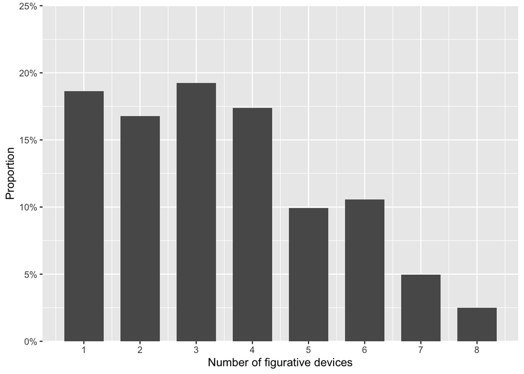

```r
ads |>
  count(id) |>
  count(n) |>
  mutate(p = nn / sum(nn),
         perc = round(p, 3) * 100,
         perc = str_c(perc, '%')) |>
  ggplot(aes(x = n, y = p)) +
  scale_x_continuous(breaks = 1:8) +
  scale_y_continuous(limits = c(0, 0.25),
                     breaks = seq(0, 0.25, 0.05),
                     labels = str_c(seq(0, 25, 5), '%'),
                     expand = c(0, 0)) +
  xlab('Number of figurative devices') +
  ylab('Proportion') +
  geom_col(width = 0.7)
```

```r
ggsave('../figures/png/number_of_figurative_deviced.png',
       width = 5.2, height = 3.8)
```

What is the average number of figurative devices?

```r
ads |>
  count(id) |>
  summarize(mean_figurative = mean(n),
            median_figurative = median(n))
```

```
## # A tibble: 1 × 2
##   mean_figurative median_figurative
##             <dbl>             <int>
## 1            3.47                 3
```

Let’s look at the same across time:

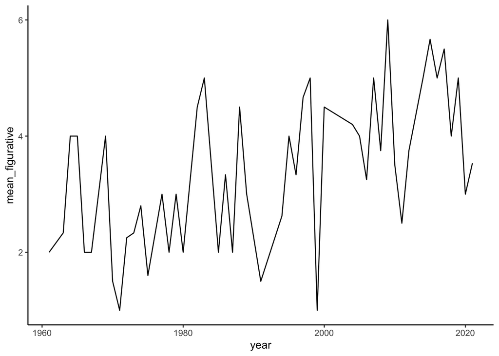

```r
ads |>
  count(id, year) |>
  group_by(year) |>
  summarize(mean_figurative = mean(n)) |>
  ggplot(aes(x = year, y = mean_figurative)) +
  geom_line() +
  theme_classic()
```

Nice… looks like a relatively clear upwards trend: more figurative devices as time goes on. Let’s look at this using the more coarse decades variable (`year_binned`):

```r
ads |>
  count(id, year_binned) |>
  group_by(year_binned) |>
  summarize(mean_figurative = mean(n))
```

```
## # A tibble: 7 × 2
##   year_binned mean_figurative
##         <dbl>           <dbl>
## 1        1960            3
## 2        1970            2.52
## 3        1980            3.31
## 4        1990            3.19
## 5        2000            4.12
## 6        2010            4.32
## 7        2020            3.39
```

Check modality over time using decades:

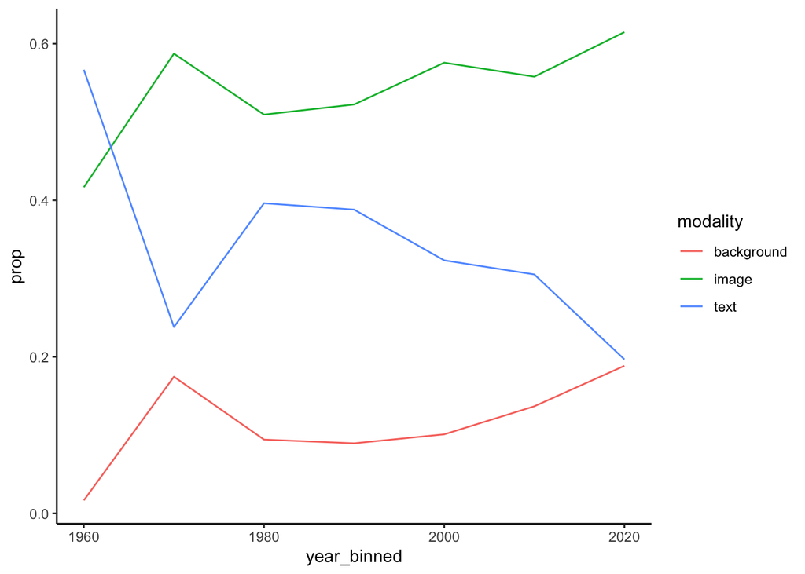

```r
ads |>
  count(year_binned, modality) |>
  group_by(year_binned) |>
  mutate(prop = n / sum(n)) |>
  ggplot(aes(x = year_binned, y = prop, color = modality)) +
  geom_line() +
  theme_classic()
```

```r
ggsave('../figures/png/modality_over_time.png',
       width = 4, height = 2.5)
```

Nice. Looks like there is a small trend towards more image figurative devices, and definitely a relative decline in text. We’ll model that later!

Let’s look at the `fig_type` variable for other/nature:

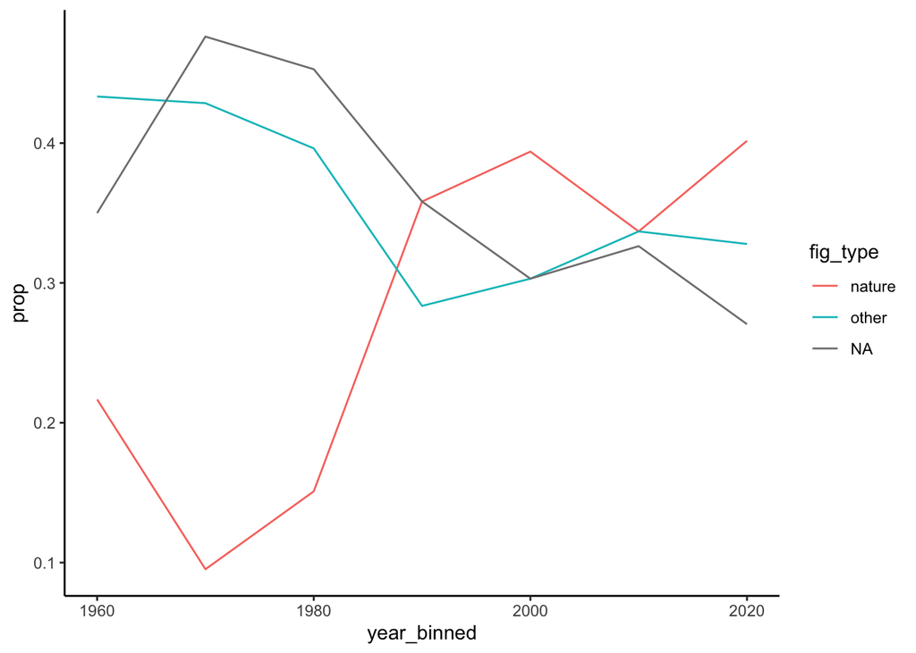

```r
ads |>
  count(year_binned, fig_type) |>
  group_by(year_binned) |>
  mutate(prop = n / sum(n)) |>
  ggplot(aes(x = year_binned, y = prop, color = fig_type)) +
  geom_line() +
  theme_classic()
```

```r
ggsave('../figures/png/figurative_type_over_time.png',
       width = 4, height = 2.5)
```

Definitely more nature metaphors over time.

Let’s look at metaphor vis-a-vis metonymy vis-a-vis personification, first across the entire dataset:

```r
ads |>
  count(fig_device) |>
  mutate(prop = n / sum(n),
            perc = round(prop, 3) * 100)
```

```
## # A tibble: 3 × 4
##   fig_device          n  prop  perc
##   <chr>           <int> <dbl> <dbl>
## 1 Metaphor          131 0.234  23.4
## 2 Metonymy          320 0.572  57.2
## 3 Personification   108 0.193  19.3
```

Close to 60% metonymy, 20% metaphor and personification.

Let’s look at metaphor vis-a-vis metonymy vis-a-vis personification over time, using the coarse `year_binned` variable:

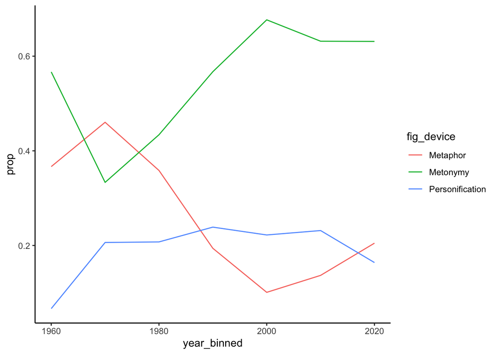

```r
ads |>
  count(year_binned, fig_device) |>
  group_by(year_binned) |>
  mutate(prop = n / sum(n)) |>
  ggplot(aes(x = year_binned, y = prop, color = fig_device)) +
  geom_line() +
  theme_classic()
```

```r
ggsave('../figures/png/figurative_device_over_time.png',
       width = 4, height = 2.5)
```

Slightly more metonymy over time, less metaphor?

# 5 Models:

Everything in the above are counts, so Poisson/Negative Binomial models seem like a good starting point. I’m using negbinomial here because it’s the more conservative approach and then I don’t have to worry checking for overdispersion (excess variance) as the negbinomial has a parameter to estimate that.

We’ll just use a simple `id` random effect to control for repeated measures per ad… for now, let’s not worry about any company or brand random effects.

For now, let’s make models of:

- number of figurative devices per ad over time
- number of metaphors, metonymies, and personification across time
- rise of nature metaphors over time
- text versus image

## 5.1 N of figurative devices over time

For now, just default priors (more thinking incoming).

```r
# Setup data frame:

fig_n_df <- ads |> count(year, id)

# Check:

fig_n_df

# Set n - 1 since each ad has at least one device:

fig_n_df <- mutate(fig_n_df, n = n - 1)

# Model 'n' over 'year', each data point is one ad, so no random effect for 'id' needed:

fig_n_mdl <- brm(n ~ 1 + year,
                 data = fig_n_df,
                 family = negbinomial,

                 # MCMC settings:

                 chains = 4, cores = 4,
                 iter = 4000, warmup = 2000)

# Save:

save(fig_n_mdl, file = '../models/fig_n_mdl.RData')
```

Load:

```r
load('../models/fig_n_mdl.RData')
```

Show:

```r
fig_n_mdl
```

```
##  Family: negbinomial
##   Links: mu = log; shape = identity
## Formula: n ~ 1 + year
##    Data: fig_n_df (Number of observations: 170)
##   Draws: 4 chains, each with iter = 4000; warmup = 2000; thin = 1;
##          total post-warmup draws = 8000
##
## Regression Coefficients:
##           Estimate Est.Error l-95% CI u-95% CI Rhat Bulk_ESS Tail_ESS
## Intercept   -22.78      7.16   -36.98    -8.71 1.00     7920     6032
## year          0.01      0.00     0.00     0.02 1.00     7947     6032
##
## Further Distributional Parameters:
##       Estimate Est.Error l-95% CI u-95% CI Rhat Bulk_ESS Tail_ESS
## shape     2.78      0.81     1.65     4.70 1.00     5762     4522
##
## Draws were sampled using sampling(NUTS). For each parameter, Bulk_ESS
## and Tail_ESS are effective sample size measures, and Rhat is the potential
## scale reduction factor on split chains (at convergence, Rhat = 1).
```

Looks like nice year effect:

```r
# hypothesis(fig_n_mdl, 'year > 0')
```

Extract conditional effects for plotting:

```r
fig_n_df <- conditional_effects(fig_n_mdl)$year
```

Make a plot of the curve:

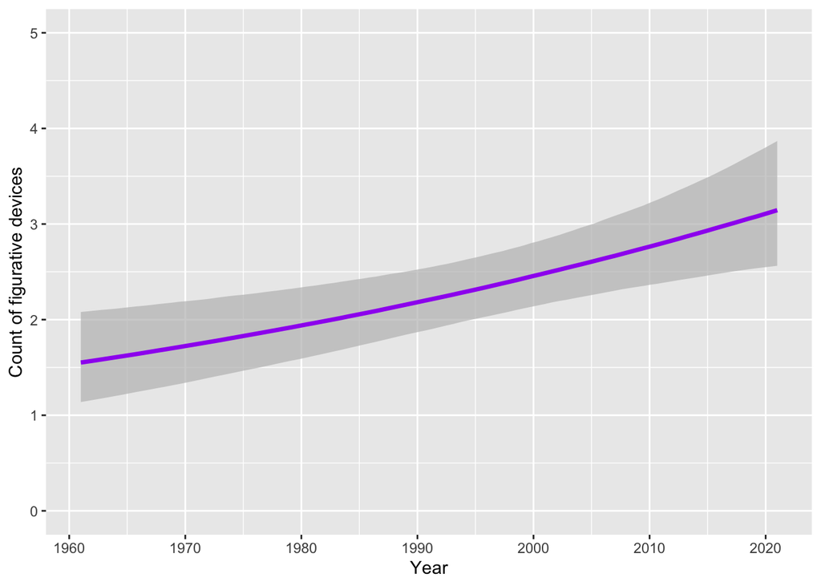

```r
# Plot core:

fig_n_p <- fig_n_df |>
  ggplot(aes(x = year, y = estimate__,
             ymin = lower__, ymax = upper__)) +
  geom_ribbon(fill = 'grey', alpha = 0.7) +
  geom_line(col = 'purple', size = 1.25)
# Axes and labels:

fig_n_p <- fig_n_p +
  scale_x_continuous(breaks = seq(1960, 2020, 10)) +
  scale_y_continuous(breaks = 0:5, labels = 0:5,
                     limits = c(0, 5)) +
  xlab('Year') +
  ylab('Count of figurative devices')

# Show and save:

fig_n_p
```

```r
ggsave('../figures/pdf/figurative_device_number.pdf', fig_n_p,
       width = 5.8, height = 3.7)
ggsave('../figures/png/figurative_device_number.png', fig_n_p,
       width = 5.8, height = 3.7)
```

Same thing but with smoothing term to compare:

```r
# Model 'n' over 'year', each data point is one ad, so no random effect for 'id' needed:

fig_n_gam <- brm(n ~ 1 + s(year),
                 data = fig_n_df,
                 family = negbinomial,

                 # MCMC settings:

                 chains = 4, cores = 4,
                 iter = 7000, warmup = 5000,
                 control = list(adapt_delta = 0.99))

# Save:

save(fig_n_gam, file = '../models/fig_n_gam.RData')
```

Load:

```r
load('../models/fig_n_gam.RData')
```

Show:

```r
fig_n_gam
```

```
##  Family: negbinomial
##   Links: mu = log; shape = identity
## Formula: n ~ 1 + s(year)
##    Data: fig_n_df (Number of observations: 170)
##   Draws: 4 chains, each with iter = 7000; warmup = 5000; thin = 1;
##          total post-warmup draws = 8000
##
## Smoothing Spline Hyperparameters:
##              Estimate Est.Error l-95% CI u-95% CI Rhat Bulk_ESS Tail_ESS
## sds(syear_1)     1.25      1.03     0.05     3.84 1.00     1765     2347
##
## Regression Coefficients:
##           Estimate Est.Error l-95% CI u-95% CI Rhat Bulk_ESS Tail_ESS
## Intercept     0.80      0.07     0.67     0.93 1.00     7584     6030
## syear_1      -1.39      3.42    -9.90     3.06 1.00     2127     2217
##
## Further Distributional Parameters:
##       Estimate Est.Error l-95% CI u-95% CI Rhat Bulk_ESS Tail_ESS
## shape     4.26     20.60     1.92     7.79 1.00     5220     2746
##
## Draws were sampled using sampling(NUTS). For each parameter, Bulk_ESS
## and Tail_ESS are effective sample size measures, and Rhat is the potential
## scale reduction factor on split chains (at convergence, Rhat = 1).
```

Extract conditional effects for plotting:

```r
fig_n_df <- conditional_effects(fig_n_gam)$year
```

Make a plot of the curve:

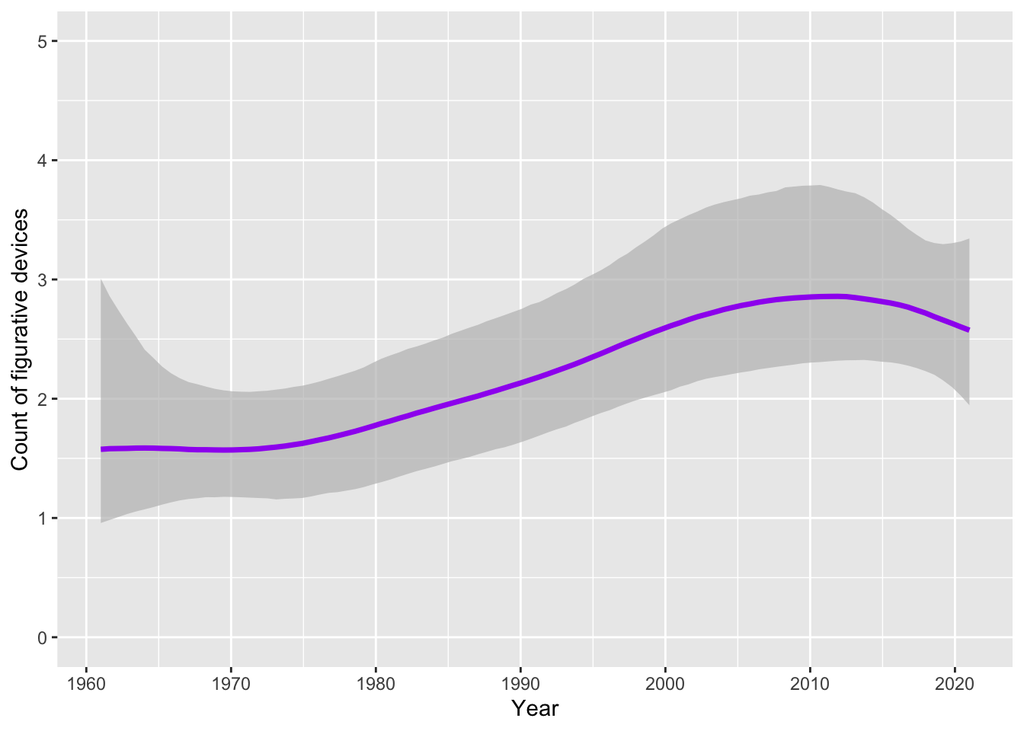

```r
# Plot core:

fig_n_p <- fig_n_df |>
  ggplot(aes(x = year, y = estimate__,
             ymin = lower__, ymax = upper__)) +
  geom_ribbon(fill = 'grey', alpha = 0.7) +
  geom_line(col = 'purple', size = 1.25)

# Axes and labels:

fig_n_p <- fig_n_p +
  scale_x_continuous(breaks = seq(1960, 2020, 10)) +
  scale_y_continuous(breaks = 0:5, labels = 0:5,
                     limits = c(0, 5)) +
  xlab('Year') +
  ylab('Count of figurative devices')

# Show and save:

fig_n_p
```

```r
ggsave('../figures/pdf/figurative_device_number_gam.pdf', fig_n_p,
       width = 5.8, height = 3.7)
ggsave('../figures/png/figurative_device_number_gam.png', fig_n_p,
       width = 5.8, height = 3.7)
```

## 5.2 Metaphor/metonymy/personification over time

```r
# Setup data frame:

fig_device_df <- ads |>
  count(year, id, fig_device) |>
  pivot_wider(values_from = n, names_from = fig_device, values_fill = 0) |>
  pivot_longer(cols = Metaphor:Personification, names_to = 'fig_device', values_to = 'n')

# Check:

fig_device_df

# Convert to factor with personification as reference level:

fig_device_df <- mutate(fig_device_df,
                        fig_device = factor(fig_device, levels = c('Personification',
                                                                   'Metaphor', 'Metonymy')))

# Model 'n' over 'year' and which device, now we have 3 data points per ad, so adding random effect:

fig_dev_mdl <- brm(n ~ 1 + year + fig_device +
                     year:fig_device +
                     (1|id),
                   data = fig_device_df,
                   family = negbinomial,

                   # MCMC settings:

                   chains = 4, cores = 4,
                   iter = 4000, warmup = 2000)

# Save:

save(fig_dev_mdl, file = '../models/fig_dev_mdl.RData')
```

Load:

```r
load('../models/fig_dev_mdl.RData')
```

Show:

```r
fig_dev_mdl
```

```
##  Family: negbinomial
##   Links: mu = log; shape = identity
## Formula: n ~ 1 + year + fig_device + year:fig_device + (1 | id)
##    Data: fig_device_df (Number of observations: 510)
##   Draws: 4 chains, each with iter = 4000; warmup = 2000; thin = 1;
##          total post-warmup draws = 8000
##
## Multilevel Hyperparameters:
## ~id (Number of levels: 161)
##               Estimate Est.Error l-95% CI u-95% CI Rhat Bulk_ESS Tail_ESS
## sd(Intercept)     0.13      0.09     0.01     0.32 1.00     1218     2856
##
## Regression Coefficients:
##                         Estimate Est.Error l-95% CI u-95% CI Rhat Bulk_ESS
## Intercept                 -27.91     10.67   -49.14    -7.23 1.00     2376
## year                        0.01      0.01     0.00     0.02 1.00     2378
## fig_deviceMetaphor         52.43     13.98    25.34    80.09 1.00     2454
## fig_deviceMetonymy         -1.78     12.44   -26.08    22.96 1.00     2441
## year:fig_deviceMetaphor    -0.03      0.01    -0.04    -0.01 1.00     2462
## year:fig_deviceMetonymy     0.00      0.01    -0.01     0.01 1.00     2444
##                         Tail_ESS
## Intercept                   3073
## year                        3018
## fig_deviceMetaphor          3484
## fig_deviceMetonymy          3299
## year:fig_deviceMetaphor     3487
## year:fig_deviceMetonymy     3299
##
## Further Distributional Parameters:
##       Estimate Est.Error l-95% CI u-95% CI Rhat Bulk_ESS Tail_ESS
## shape  1370.25  42752.53     3.77   512.65 1.00     2079     1437
##
## Draws were sampled using sampling(NUTS). For each parameter, Bulk_ESS
## and Tail_ESS are effective sample size measures, and Rhat is the potential
## scale reduction factor on split chains (at convergence, Rhat = 1).
```

Looks like nice year effect for the reference category (personification):

```r
hypothesis(fig_dev_mdl, 'year > 0')
```

```
## Hypothesis Tests for class b:
##   Hypothesis Estimate Est.Error CI.Lower CI.Upper Evid.Ratio Post.Prob Star
## 1 (year) > 0     0.01      0.01     0.01     0.02        249         1    *
## ---
## 'CI': 90%-CI for one-sided and 95%-CI for two-sided hypotheses.
## '*': For one-sided hypotheses, the posterior probability exceeds 95%;
## for two-sided hypotheses, the value tested against lies outside the 95%-CI.
## Posterior probabilities of point hypotheses assume equal prior probabilities.
```

```r
hypothesis(fig_dev_mdl, 'year + year:fig_deviceMetaphor < 0')
```

```
## Hypothesis Tests for class b:
##                 Hypothesis Estimate Est.Error CI.Lower CI.Upper Evid.Ratio
## 1 (year+year:fig_de... < 0    -0.01         0    -0.02        0     176.78
##   Post.Prob Star
## 1      0.99    *
## ---
## 'CI': 90%-CI for one-sided and 95%-CI for two-sided hypotheses.
## '*': For one-sided hypotheses, the posterior probability exceeds 95%;
## for two-sided hypotheses, the value tested against lies outside the 95%-CI.
## Posterior probabilities of point hypotheses assume equal prior probabilities.
```

```r
hypothesis(fig_dev_mdl, 'year + year:fig_deviceMetonymy > 0')
```

```
## Hypothesis Tests for class b:
##                 Hypothesis Estimate Est.Error CI.Lower CI.Upper Evid.Ratio
## 1 (year+year:fig_de... > 0     0.02         0     0.01     0.02        Inf
##   Post.Prob Star
## 1         1    *
## ---
## 'CI': 90%-CI for one-sided and 95%-CI for two-sided hypotheses.
## '*': For one-sided hypotheses, the posterior probability exceeds 95%;
## for two-sided hypotheses, the value tested against lies outside the 95%-CI.
## Posterior probabilities of point hypotheses assume equal prior probabilities.
```

More metonymy and personification over time, less metaphor over time.

## 5.3 Nature over time

See whether metonymies and metaphors related to nature have increased over time.

This will be a logistic regression model as we’re looking at the proportion of nature metaphors/metonymies out of the total number of figurative devices:

```r
ads |>
  count(fig_type)
```

```
## # A tibble: 3 × 2
##   fig_type     n
##   <chr>    <int>
## 1 nature     171
## 2 other      195
## 3 <NA>       193
```

Create a nature versus rest variable out of this:

```r
ads <- ads |>
  mutate(nature_v_rest = if_else(fig_type == 'nature', 'nature', 'other'),
         nature_v_rest = if_else(is.na(nature_v_rest), 'other', nature_v_rest))
```

Let’s look at the `fig_type` variable for other/nature:

```r
# Factor code:

ads <- ads |>
  mutate(nature_v_rest = factor(nature_v_rest, levels = c('other', 'nature')))

# Proportion of nature metaphor/metonymy over time:

nature_mdl <- brm(nature_v_rest ~ 1 + s(year),
                   data = ads,
                   family = bernoulli,

                   # MCMC settings:

                   chains = 4, cores = 4,
                   iter = 7000, warmup = 5000,
                  control = list(adapt_delta = 0.99))

# Save:

save(nature_mdl, file = '../models/nature_mdl.RData')
```

Load:

```r
load('../models/nature_mdl.RData')
```

Show:

```r
nature_mdl
```

```
##  Family: bernoulli
##   Links: mu = logit
## Formula: nature_v_rest ~ 1 + s(year)
##    Data: ads (Number of observations: 559)
##   Draws: 4 chains, each with iter = 7000; warmup = 5000; thin = 1;
##          total post-warmup draws = 8000
##
## Smoothing Spline Hyperparameters:
##              Estimate Est.Error l-95% CI u-95% CI Rhat Bulk_ESS Tail_ESS
## sds(syear_1)     2.11      1.49     0.13     5.74 1.00     2022     2650
##
## Regression Coefficients:
##           Estimate Est.Error l-95% CI u-95% CI Rhat Bulk_ESS Tail_ESS
## Intercept    -0.88      0.10    -1.07    -0.69 1.00     8491     5399
## syear_1      -1.07      4.78   -12.51     6.01 1.00     1999     3100
##
## Draws were sampled using sampling(NUTS). For each parameter, Bulk_ESS
## and Tail_ESS are effective sample size measures, and Rhat is the potential
## scale reduction factor on split chains (at convergence, Rhat = 1).
```

Hypothesis tests:

```r
# hypothesis(nature_mdl, 'year > 0')
```

Extract conditional effects for plotting:

```r
fig_n_df <- conditional_effects(nature_mdl)$year
```

Make a plot of the curve:

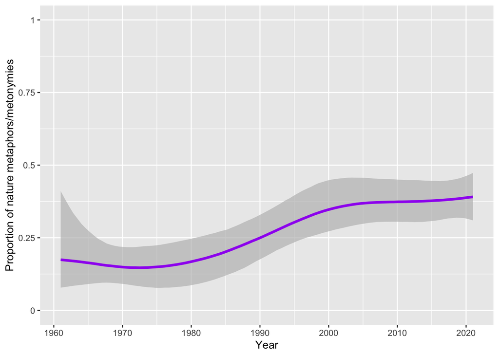

```r
# Plot core:

fig_n_p <- fig_n_df |>
  ggplot(aes(x = year, y = estimate__,
             ymin = lower__, ymax = upper__)) +
  geom_ribbon(fill = 'grey', alpha = 0.7) +
  geom_line(col = 'purple', size = 1.25)

# Axes and labels:

fig_n_p <- fig_n_p +
  scale_x_continuous(breaks = seq(1960, 2020, 10)) +
  scale_y_continuous(breaks = seq(0, 1, 0.25), labels = seq(0, 1, 0.25),
                     limits = c(0, 1)) +
  xlab('Year') +
  ylab('Proportion of nature metaphors/metonymies')

# Show and save:

fig_n_p
```

```r
ggsave('../figures/pdf/nature_over_time_gam.pdf', fig_n_p,
       width = 5.8, height = 3.7)
ggsave('../figures/png/nature_over_time_gam.png', fig_n_p,
       width = 5.8, height = 3.7)
```

## 5.4 Image versus text

Image versus text and since that has a upper bound/total, let’s do that in logistic regression:

```r
# Setup data frame:

modality_df <- ads |>
  count(year, id, modality) |>
  pivot_wider(values_from = n, names_from = modality, values_fill = 0) |>
  pivot_longer(cols = text:background, names_to = 'modality', values_to = 'n')

# Add total:

modality_df <- ads |>
  count(id) |>
  rename(total = n) |>
  right_join(modality_df)

# Check:

modality_df

# Convert to factor with personification as reference level:

modality_df <- mutate(modality_df,
                      modality = factor(modality, levels = c('background',
                                                             'text', 'image')))

# Model 'n' over 'year' and which device, now we have 3 data points per ad, so adding random effect:

modality_mdl <- brm(n | trials(total) ~ 1 + year + modality +
                      year:modality +
                     (1|id),
                   data = modality_df,
                   family = binomial,

                   # MCMC settings:

                   chains = 4, cores = 4,
                   iter = 4000, warmup = 2000)

# Save:

save(modality_mdl, file = '../models/modality_mdl.RData')
```

Load:

```r
load('../models/modality_mdl.RData')
```

Show:

```r
modality_mdl
```

```
##  Family: binomial
##   Links: mu = logit
## Formula: n | trials(total) ~ 1 + year + modality + year:modality + (1 | id)
##    Data: modality_df (Number of observations: 510)
##   Draws: 4 chains, each with iter = 4000; warmup = 2000; thin = 1;
##          total post-warmup draws = 8000
##
## Multilevel Hyperparameters:
## ~id (Number of levels: 161)
##               Estimate Est.Error l-95% CI u-95% CI Rhat Bulk_ESS Tail_ESS
## sd(Intercept)     0.05      0.04     0.00     0.16 1.00     4363     3240
##
## Regression Coefficients:
##                    Estimate Est.Error l-95% CI u-95% CI Rhat Bulk_ESS Tail_ESS
## Intercept            -41.84     14.69   -71.05   -13.26 1.00     1572     2771
## year                   0.02      0.01     0.01     0.03 1.00     1573     2770
## modalitytext          67.16     17.16    33.80   101.23 1.00     1669     3090
## modalityimage         12.56     17.07   -21.39    46.60 1.00     1680     3369
## year:modalitytext     -0.03      0.01    -0.05    -0.02 1.00     1671     3128
## year:modalityimage    -0.01      0.01    -0.02     0.01 1.00     1681     3376
##
## Draws were sampled using sampling(NUTS). For each parameter, Bulk_ESS
## and Tail_ESS are effective sample size measures, and Rhat is the potential
## scale reduction factor on split chains (at convergence, Rhat = 1).
```

Ok, so an upwards slope of `year` for the reference level, which is background, and then that trend is reverted for text and slightly dampened for image.

```r
hypothesis(modality_mdl, 'year > 0') # background
```

```
## Hypothesis Tests for class b:
##   Hypothesis Estimate Est.Error CI.Lower CI.Upper Evid.Ratio Post.Prob Star
## 1 (year) > 0     0.02      0.01     0.01     0.03     346.83         1    *
## ---
## 'CI': 90%-CI for one-sided and 95%-CI for two-sided hypotheses.
## '*': For one-sided hypotheses, the posterior probability exceeds 95%;
## for two-sided hypotheses, the value tested against lies outside the 95%-CI.
## Posterior probabilities of point hypotheses assume equal prior probabilities.
```

```r
hypothesis(modality_mdl, 'year + year:modalitytext < 0') # text
```

```
## Hypothesis Tests for class b:
##                 Hypothesis Estimate Est.Error CI.Lower CI.Upper Evid.Ratio
## 1 (year+year:modali... < 0    -0.01         0    -0.02    -0.01     726.27
##   Post.Prob Star
## 1         1    *
## ---
## 'CI': 90%-CI for one-sided and 95%-CI for two-sided hypotheses.
## '*': For one-sided hypotheses, the posterior probability exceeds 95%;
## for two-sided hypotheses, the value tested against lies outside the 95%-CI.
## Posterior probabilities of point hypotheses assume equal prior probabilities.
```

```r
hypothesis(modality_mdl, 'year + year:modalityimage > 0') # image
```

```
## Hypothesis Tests for class b:
##                 Hypothesis Estimate Est.Error CI.Lower CI.Upper Evid.Ratio
## 1 (year+year:modali... > 0     0.01         0     0.01     0.02       3999
##   Post.Prob Star
## 1         1    *
## ---
## 'CI': 90%-CI for one-sided and 95%-CI for two-sided hypotheses.
## '*': For one-sided hypotheses, the posterior probability exceeds 95%;
## for two-sided hypotheses, the value tested against lies outside the 95%-CI.
## Posterior probabilities of point hypotheses assume equal prior probabilities.
```

Confident in positive trends for background and image over time, and negative trend for text over time.

Model text versus image + background (= visual).

```r
ads <- ads |>
  mutate(modality_red = if_else(modality == 'text', 'text', 'visual'))
```

Make a model of this:

```r
# Make into factor:

ads <- ads |>
  mutate(modality_red = factor(modality_red,
                               levels = c('text', 'visual')))

# Model proportion over year:

visual_mdl <- brm(modality_red ~ 1 + s(year) +
                     (1|id),
                   data = ads,
                   family = bernoulli,

                   # MCMC settings:

                   chains = 4, cores = 4,
                   iter = 6000, warmup = 3000,
                   control = list(adapt_delta = 0.98))

# Save:

save(visual_mdl, file = '../models/visual_mdl.RData')
```

Load model:

```r
load('../models/visual_mdl.RData')
```

Extract conditional effects for plotting:

```r
fig_n_df <- conditional_effects(visual_mdl)$year
```

Make a plot of the curve:

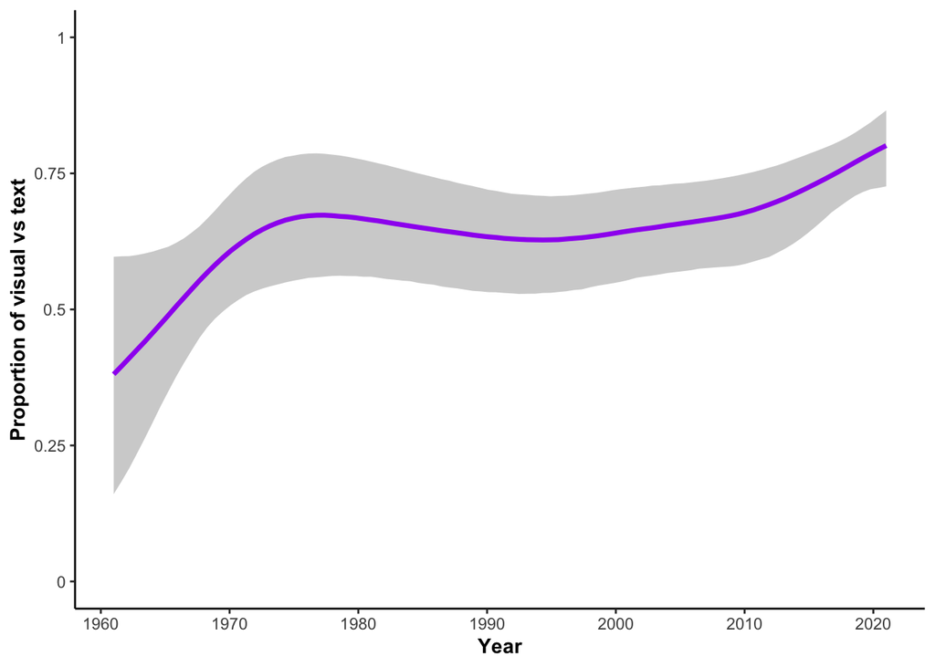

```r
# Plot core:

fig_n_p <- fig_n_df |>
  ggplot(aes(x = year, y = estimate__,
             ymin = lower__, ymax = upper__)) +
  geom_ribbon(fill = 'grey', alpha = 0.7) +
  geom_line(col = 'purple', size = 1.25)

# Axes and labels:

fig_n_p <- fig_n_p +
  scale_x_continuous(breaks = seq(1960, 2020, 10)) +
  scale_y_continuous(breaks = seq(0, 1, 0.25), labels = seq(0, 1, 0.25),
                     limits = c(0, 1)) +
  xlab('Year') +
  ylab('Proportion of visual vs text') +
  theme_classic() +
  theme(axis.title.x = element_text(face = 'bold'),
        axis.title.y = element_text(face = 'bold'))

# Show and save:

fig_n_p
```

```r
ggsave('../figures/pdf/visual_v_text.pdf', fig_n_p,
       width = 5.8, height = 3.7)
ggsave('../figures/png/visual_v_text.png', fig_n_p,
       width = 5.8, height = 3.7)
```

This completes this analysis.